# 数据可视化

## 7.2 position参数

- 1 `position = "stack"`

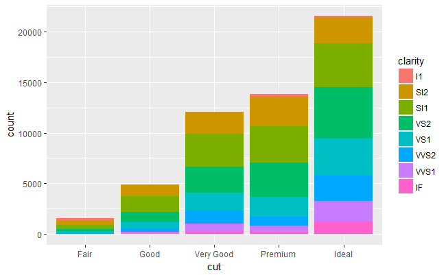

```r
ggplot(data = diamonds) +
  geom_bar(mapping = aes(x = cut, fill = clarity), position = "stack")
```

- 2 `position = "identity"`  
  Place each object exactly where it falls in the context of the graph. This is not very useful for bars, because it overlaps them. The identity position adjustment is more useful for 2d geoms, like points, where it is the default.

通过设置透明度或不填充颜色，来观察 `position = "identity"` 的作用

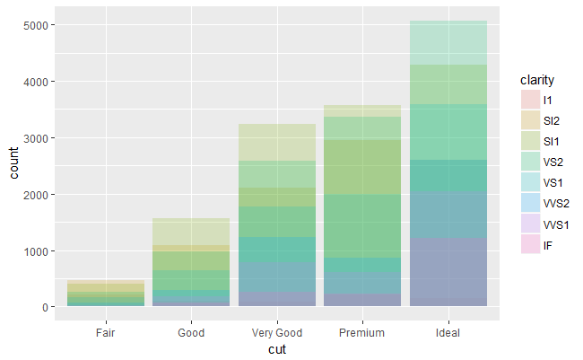

```r
ggplot(data = diamonds, mapping = aes(x = cut, fill = clarity)) +
  geom_bar(alpha = 1/5, position = "identity")
```

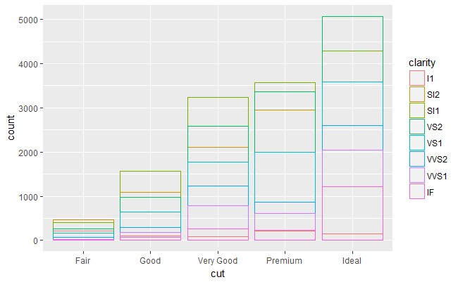

```r
ggplot(data = diamonds, mapping = aes(x = cut, colour = clarity)) +
  geom_bar(fill = NA, position = "identity")
```

- 3 `position = "fill"`  
  Works like stacking, but makes each set of stacked bars the same height. This makes it easier to compare proportions across groups.

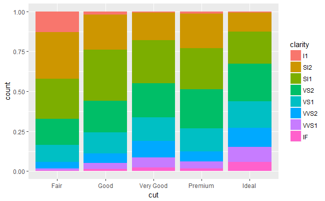

```r
ggplot(data = diamonds) +
  geom_bar(mapping = aes(x = cut, fill = clarity), position = "fill")
```

- 4 `position = "dodge"`  
  Places overlapping objects directly beside one another. This makes it easier to compare individual values.

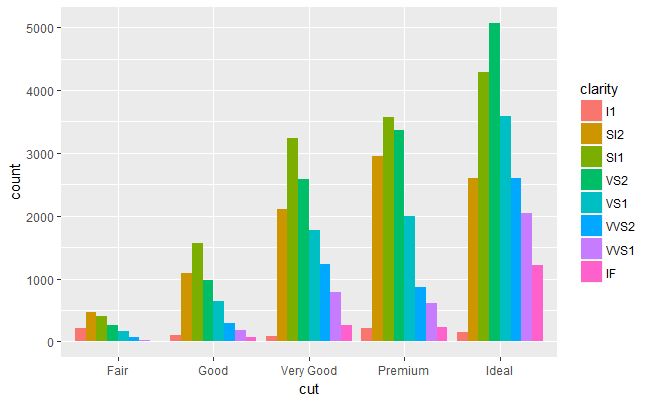

```r
ggplot(data = diamonds) +
  geom_bar(mapping = aes(x = cut, fill = clarity), position = "dodge")
```

- 5 `position = "jitter"`  
  Adds a small amount of random noise to each point. This spreads the points out because no two points are likely to receive the same amount of random noise.

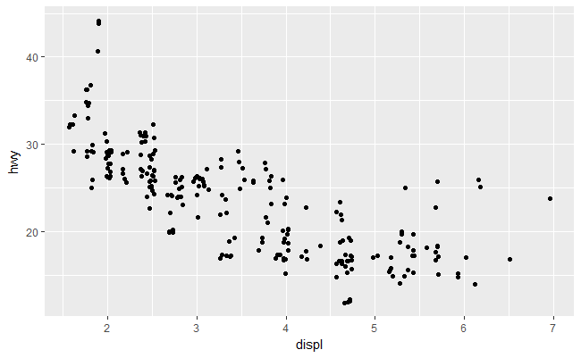

```r
ggplot(data = mpg) +
  geom_point(mapping = aes(x = displ, y = hwy), position = "jitter")
```

`geom_jitter` 效果相同

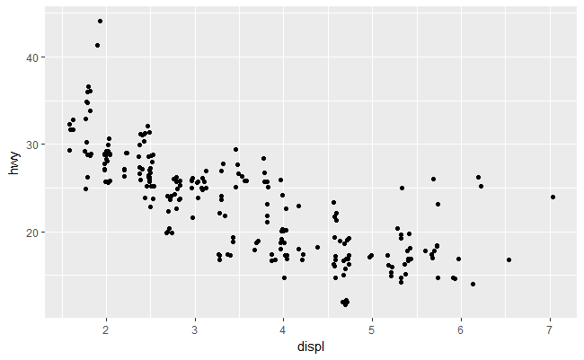

```r
ggplot(data = mpg) +
  geom_jitter(mapping = aes(x = displ, y = hwy))
```

# 8 坐标系统

- 1 `coord_flip()`  
  Switches the x and y axes. This is useful (for example), if you want horizontal boxplots. It’s also useful for long labels: it’s hard to get them to fit without overlapping on the x-axis.

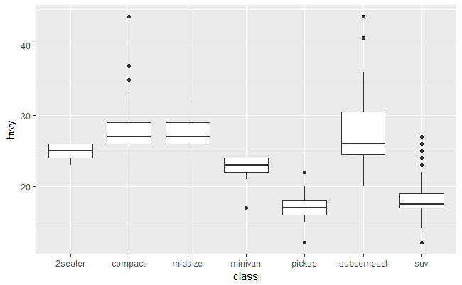

```r
ggplot(data = mpg, mapping = aes(x = class, y = hwy)) +
  geom_boxplot()
```

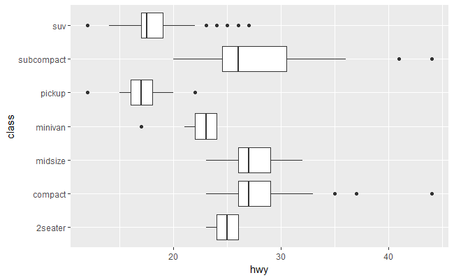

```r
ggplot(data = mpg, mapping = aes(x = class, y = hwy)) +
  geom_boxplot() +
  coord_flip()
```

- 2 `coord_quickmap()`  
  Sets the aspect ratio correctly for maps. This is very important if you’re plotting spatial data with ggplot2.

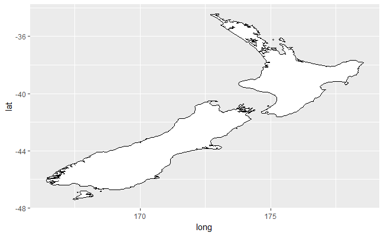

```r
nz <- map_data("nz")
ggplot(nz, aes(long, lat, group = group)) +
  geom_polygon(fill = "white", colour = "black")
```

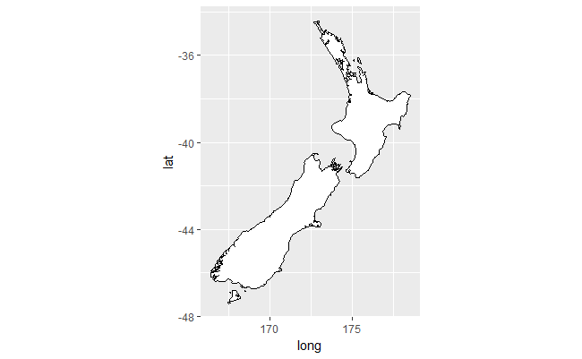

```r
ggplot(nz, aes(long, lat, group = group)) +
  geom_polygon(fill = "white", colour = "black") +
  coord_quickmap()
```

- 3 `coord_polar()`  
  Uses polar coordinates.

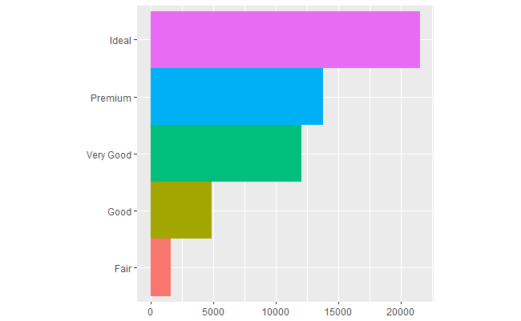

```r
bar <- ggplot(data = diamonds) +
  geom_bar(
    mapping = aes(x = cut, fill = cut),
    show.legend = FALSE,
    width = 1
  ) +
  theme(aspect.ratio = 1) +
  labs(x = NULL, y = NULL)
bar + coord_flip()
```

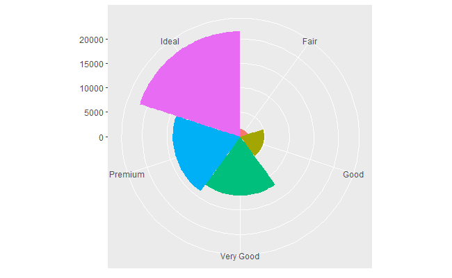

```r
bar + coord_polar()
```

# 9 `ggplot`绘图语法

## 9.1 语法模板

```
ggplot(data = <DATA>) +
  <GEOM_FUNCTION>(
     mapping = aes(<MAPPINGS>),
     stat = <STAT>,
     position = <POSITION>
  ) +
  <COORDINATE_FUNCTION> +
  <FACET_FUNCTION>
```

## 9.2 绘图流程

- 1 Start with a dataset and then transform it into the information that you want to display (with a stat).

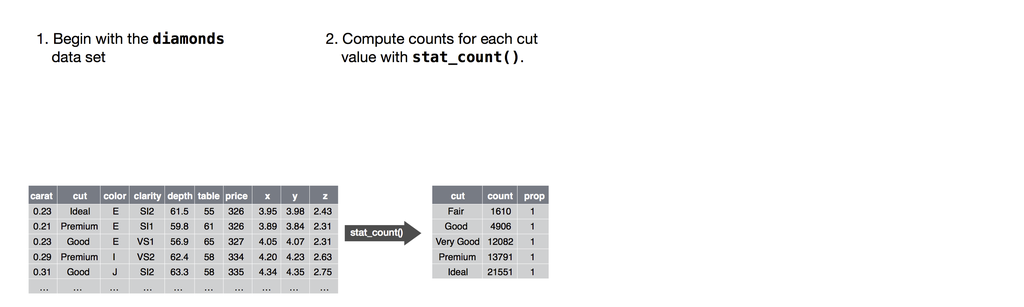

- 2 Choose a geometric object to represent each observation in the transformed data. Use the aesthetic properties of the geoms to represent variables in the data.

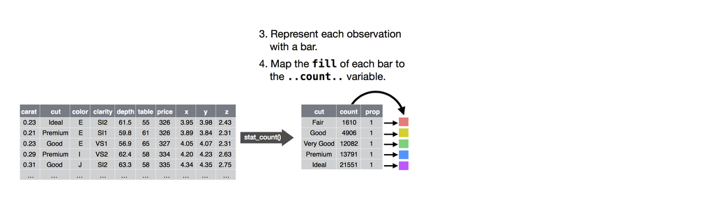

- 3 Select a coordinate system to place the geoms into. Further adjust the positions of the geoms within the coordinate system (a position adjustment) or split the graph into subplots (faceting). And extend the plot by adding one or more additional layers.

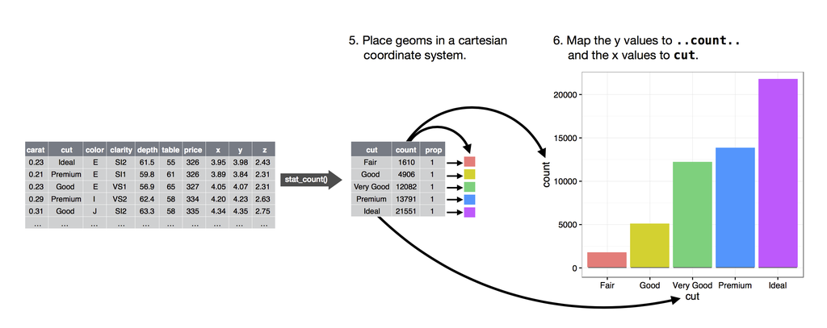